# Lab 08 - Bootstrap inference

Nonparametric statistics ay 2023/2024

2023/10/17

```r
seed=2781991
B=10000
library(progress)
```

## Bootstrapping and Nonlinear Regression

For our laboratory on Boostrapping, knowing that you’ve already seen some interesting feats in class, I decided to focus on an area where the impact of non-parametric inferential techniques are really powerful: non-linear regression.

```r
data("Orange")
Orange
```

|  | Tree | age | circumference |
| --- | --- | --- | --- |
| 1 | 1 | 118 | 30 |
| 2 | 1 | 484 | 58 |
| 3 | 1 | 664 | 87 |
| 4 | 1 | 1004 | 115 |
| 5 | 1 | 1231 | 120 |
| 6 | 1 | 1372 | 142 |
| 7 | 1 | 1582 | 145 |
| 8 | 2 | 118 | 33 |
| 9 | 2 | 484 | 69 |
| 10 | 2 | 664 | 111 |

[output cut: 25 more lines]

You see that we have a longitudinal dataset, with repeated measurements for 5 different trees. Let’s select just one of them

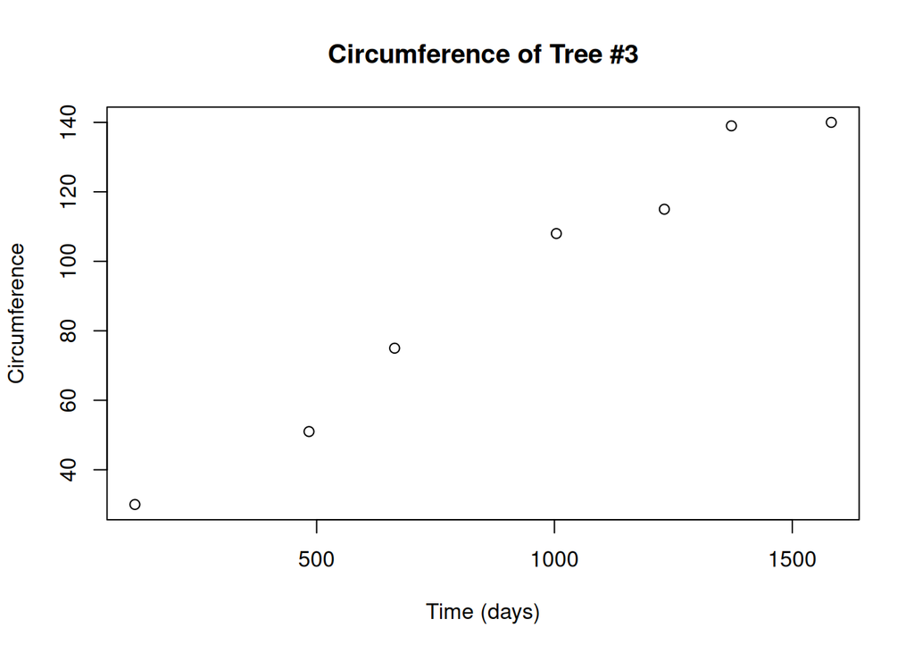

```r
O_3 <- subset(Orange, Orange$Tree == 3)
attach(O_3)
# let's have a look at the data
plot(age, circumference, main = "Circumference of Tree #3",
  xlab = "Time (days)", ylab = "Circumference")
```

The temporal evolution of the circumference seems to be relatively well described by a logistic curve… How can I estimate it?

```r
logistic <- function(t, L, k, midpoint) {
  L/(1 + exp((midpoint - t)/k))
}
```

Here $t$ is the independent variable, $L$ is the asymptote parameter, $k$ is the growth rate and $midpoint$ is the point in time when the derivative of the curve is at its maximum level (the peak, if you want an epidemic analogy). How do I estimate the parameters $L, k,midpoint$ in such nonlinear relationship? I use `nls`.

```r
model <- nls(circumference ~ logistic(age, L, k, midpoint),
  start = list(L = 150, k = 500, midpoint = 700)  # initialise variables for optimisation
  )

summary(model)
```

```
##
## Formula: circumference ~ logistic(age, L, k, midpoint)
##
## Parameters:
##          Estimate Std. Error t value Pr(>|t|)
## L          158.83      15.09  10.529  0.00046 ***
## k          400.95      74.33   5.394  0.00571 **
## midpoint   734.84     102.59   7.163  0.00201 **
## ---
## Signif. codes:  0 '***' 0.001 '**' 0.01 '*' 0.05 '.' 0.1 ' ' 1
##
## Residual standard error: 6.258 on 4 degrees of freedom
##
## Number of iterations to convergence: 4
## Achieved convergence tolerance: 6.516e-06
```

Let’s plot the estimated curve now: I need to start by generating my predictions on a fine grid

```r
age_fine <- seq(0, 2500)
circumference_fine <- predict(model, list(age = age_fine))
```

Then I plot my original points, and I overlay to them the predicted curve

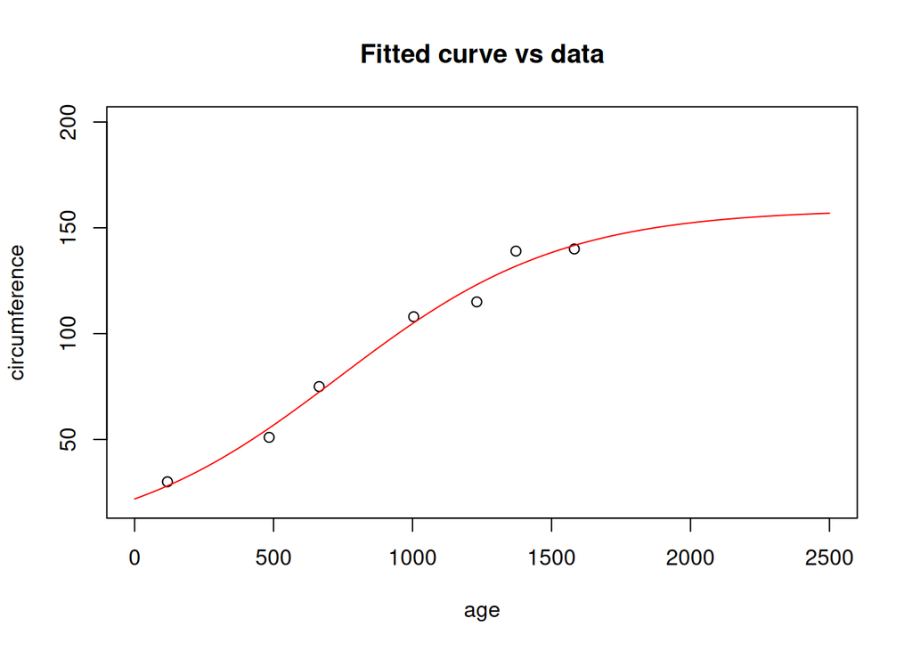

```r
plot(age, circumference, main = "Fitted curve vs data",
  xlim = c(0, 2500), ylim = c(20, 200))
lines(age_fine, circumference_fine, col = "red")
```

What if I want to make inference about these parameters? Either I impose a parametric model on the error term, or, as you expect, I can use the boostrap.

Let’s start then by computing the residuals:

```r
fitted.obs <- predict(model)
res.obs <- circumference - fitted.obs
```

And, let’s start by computing confidence intervals for the asymptote parameter

```r
L.obs <- summary(model)$parameters[1, 1]
T.boot.L <- numeric(B)
formula.b <- response.b ~ logistic(age, L, k, midpoint)

pb <- progress_bar$new(
  format = "  processing [:bar] :percent eta: :eta",
  total = B,
  clear = FALSE)

set.seed(seed)

for (b in 1:B) {
  response.b <- fitted.obs + sample(res.obs, replace = T)
  fm.b <- nls(formula.b, start = list(L = 150, k = 500, midpoint = 700))
  sm.b <- summary(fm.b)
  T.boot.L[b] <- sm.b$parameters[1, 1]
  pb$tick()
}
```

let’s now compare the bootstrap distribution of the parameter with the parameter itself…

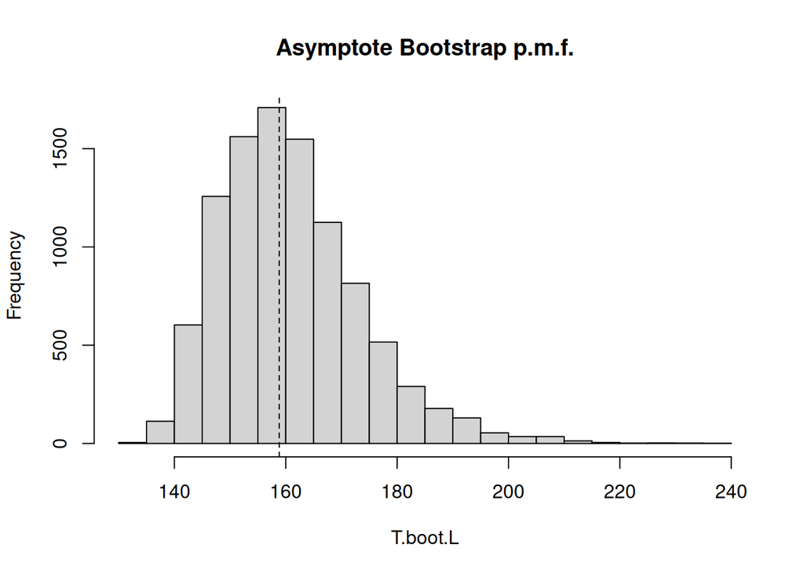

```r
hist(T.boot.L, main='Asymptote Bootstrap p.m.f.')
abline(v=L.obs, lty=2)
```

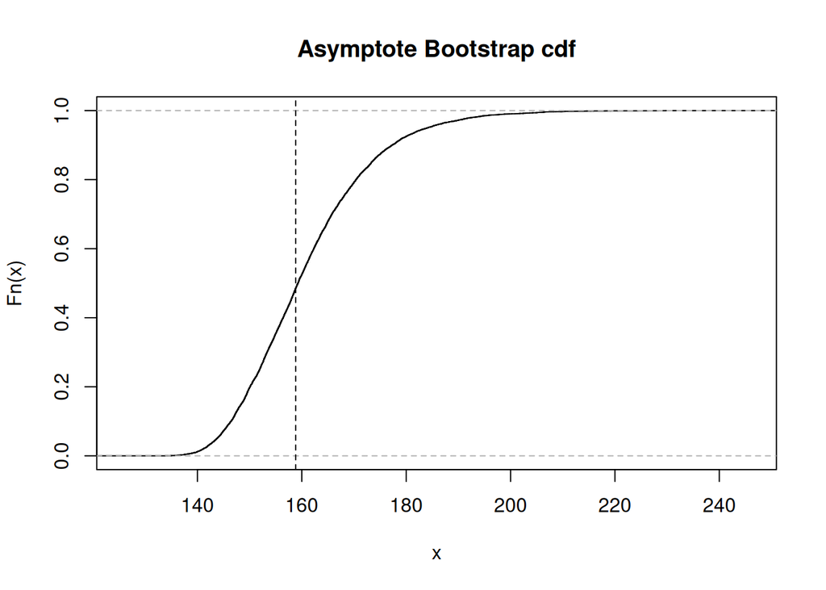

```r
plot(ecdf(T.boot.L), main='Asymptote Bootstrap cdf')
abline(v=L.obs, lty=2)
```

Using the Bootstrap distribution of the parameter, I can compute without the need of distributional assumptions and/or approximations the standard deviation of the estimate of this parameter.

```r
sd(T.boot.L)
```

```
## [1] 12.62659
```

As well as its bias

```r
bias <- mean(T.boot.L) - L.obs

MSE <- var(T.boot.L) + (bias)^2
```

What if I want to compute a confidence interval around the parameter? I can use the classical reverse-percentile approach:

```r
alpha <- 0.05
right.quantile.L <- quantile(T.boot.L, 1 - alpha/2)
left.quantile.L <- quantile(T.boot.L, alpha/2)

CI.RP.L <- c(L.obs - (right.quantile.L - L.obs),
             L.obs,
             L.obs - (left.quantile.L - L.obs))
names(CI.RP.L) <- c("lwr", "lvl", "upr")
CI.RP.L
```

```
##      lwr      lvl      upr
## 126.7201 158.8293 175.9191
```

And, let’s visualize them

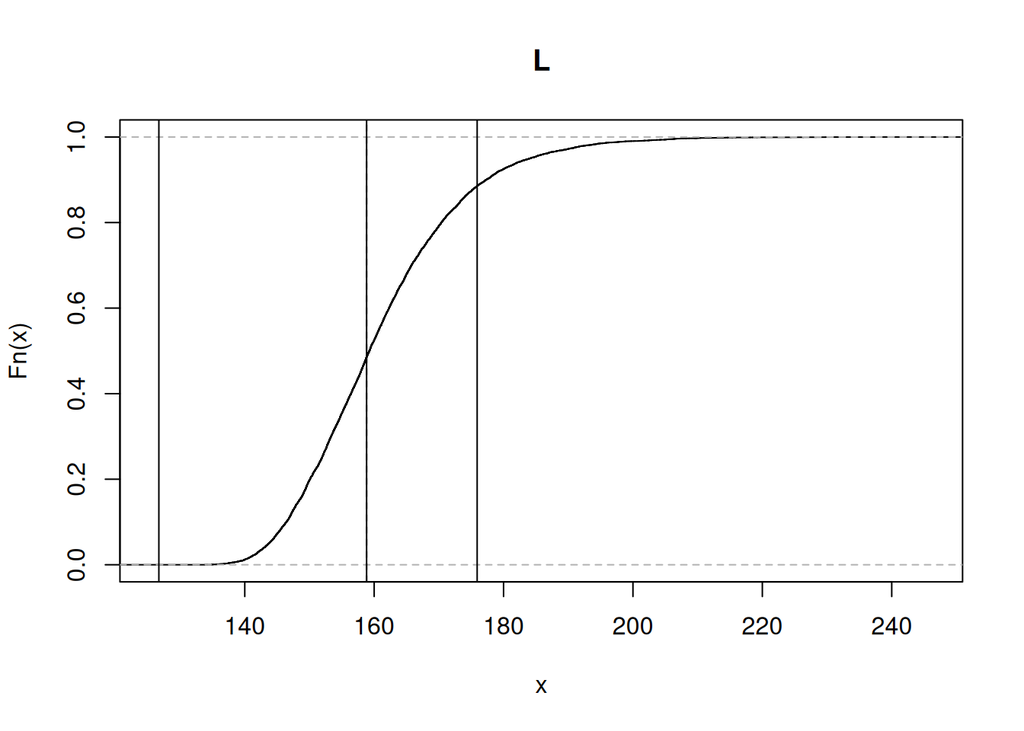

```r
plot(ecdf(T.boot.L), main = "L")
abline(v = L.obs, lty = 2)
abline(v = CI.RP.L)
```

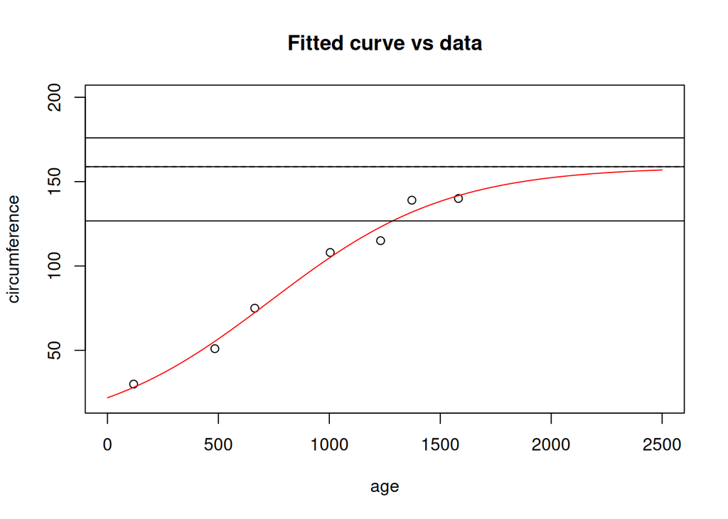

```r
plot(age, circumference, main = "Fitted curve vs data",
     xlim = c(0, 2500), ylim = c(20, 200))
lines(age_fine, circumference_fine, col = "red")
abline(h = L.obs, lty = 2)
abline(h = CI.RP.L)
```

#### ANOVA with the Bootstrap

You have already seen the Bootstrap linear regression in the lectures with Prof. Vantini. For the sake of completeness, let us use the `chickwts` dataset.

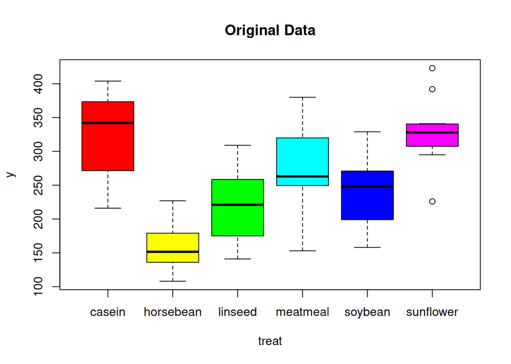

```r
attach(chickwts)
g <- nlevels(feed)
n <- dim(chickwts)[1]


plot(feed, weight, xlab='treat',col=rainbow(g),main='Original Data')
```

The null hypothesis that we want to test is that, being $\tau_i, i\in \{1,\ldots6\}$ the generic effect of a given level of the treatment.

$$H_0: \tau_i=0\;\forall i\;vs\;H_1:\exists\,\tau_i\neq0$$
And we use the $F$ statistic for the global test:

```r
fit <- lm(weight ~ feed)
summary(fit)
```

```
##
## Call:
## lm(formula = weight ~ feed)
##
## Residuals:
##      Min       1Q   Median       3Q      Max
## -123.909  -34.413    1.571   38.170  103.091
##
## Coefficients:
##               Estimate Std. Error t value Pr(>|t|)
## (Intercept)    323.583     15.834  20.436  < 2e-16 ***
## feedhorsebean -163.383     23.485  -6.957 2.07e-09 ***
## feedlinseed   -104.833     22.393  -4.682 1.49e-05 ***
## feedmeatmeal   -46.674     22.896  -2.039 0.045567 *
## feedsoybean    -77.155     21.578  -3.576 0.000665 ***
## feedsunflower    5.333     22.393   0.238 0.812495
## ---
## Signif. codes:  0 '***' 0.001 '**' 0.01 '*' 0.05 '.' 0.1 ' ' 1
##
## Residual standard error: 54.85 on 65 degrees of freedom
## Multiple R-squared:  0.5417, Adjusted R-squared:  0.5064
## F-statistic: 15.36 on 5 and 65 DF,  p-value: 5.936e-10
```

```r
T0 <- summary(fit)$fstatistic[1]  # extract the test statistic
T0
```

```
##   value
## 15.3648
```

And now we estimate via M.C. the Bootstrap distribution of such statistic. For that, remember we first need to estimate the model under $H_0$ to exchange the residuals. Since the model under $H_0$ is the empty model, whence:

```r
y.fitted <- mean(weight)
residuals.H0 <- weight - y.fitted
```

```r
T_stat <- numeric(B)
n <- dim(chickwts)[1]

for(perm in 1:B){
  # Permutation:
  permutation <- sample(1:n, replace = T)
  residuals.perm <- residuals.H0[permutation]
  y.perm <- y.fitted + residuals.perm
  fit_perm <- lm(y.perm ~ feed)

  # Test statistic:
  T_stat[perm] <- summary(fit_perm)$fstatistic[1]
}
```

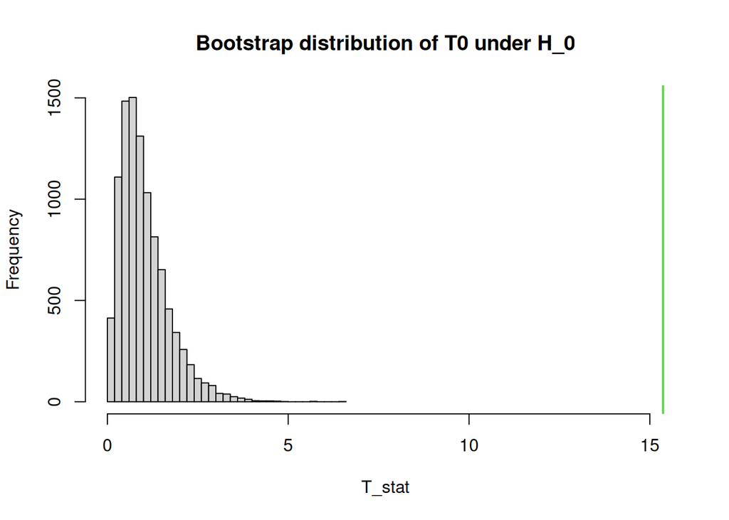

```r
hist(T_stat,xlim=range(c(T_stat,T0)),breaks=30,
     main="Bootstrap distribution of T0 under H_0")
abline(v=T0,col=3,lwd=2)
```

```r
# p-value
p_val <- sum(T_stat>=T0)/B
p_val
```

```
## [1] 0
```